# EasyVisa Project

```
Training performance:
    Accuracy    Recall  Precision        F1
0  0.758017  0.882146   0.783027  0.829636
Testing performance:
    Accuracy    Recall  Precision        F1
0   0.74516  0.876592   0.772484  0.821252
```

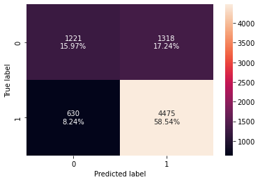

```python
#Calculating different metrics
gbc_tuned_model_train_perf=model_performance_classification_sklearn(gbc_tuned,X_train,y_train)
print("Training performance:\n",gbc_tuned_model_train_perf)
gbc_tuned_model_test_perf=model_performance_classification_sklearn(gbc_tuned,X_test,y_test)
print("Testing performance:\n",gbc_tuned_model_test_perf)

#Creating confusion matrix
confusion_matrix_sklearn(gbc_tuned,X_test,y_test)
```

XGBoost Classifier

```
Training performance:
    Accuracy    Recall  Precision       F1
0  0.832922  0.927642   0.839168  0.88119
Testing performance:
    Accuracy    Recall  Precision        F1
0  0.729853  0.856807   0.766293  0.809026
```

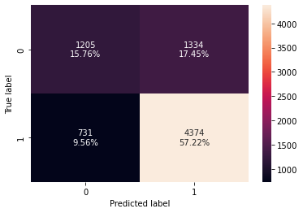

```python
xgb_classifier = XGBClassifier(random_state=1, eval_metric='logloss')
xgb_classifier.fit(X_train,y_train)

#Calculating different metrics
xgb_classifier_model_train_perf=model_performance_classification_sklearn(xgb_classifier,X_train,y_train)
print("Training performance:\n",xgb_classifier_model_train_perf)
xgb_classifier_model_test_perf=model_performance_classification_sklearn(xgb_classifier,X_test,y_test)
print("Testing performance:\n",xgb_classifier_model_test_perf)

#Creating confusion matrix
confusion_matrix_sklearn(xgb_classifier,X_test,y_test)
```

```python
xgb_tuned = XGBClassifier(random_state=1, eval_metric='logloss')

# Grid of parameters to choose from
parameters = {
    "n_estimators": [10,30,50],
    "scale_pos_weight":[1,2,5],
    "subsample":[0.7,0.9,1],
    "learning_rate":[0.05, 0.1,0.2],
    "colsample_bytree":[0.7,0.9,1],
    "colsample_bylevel":[0.5,0.7,1]
}

# Type of scoring used to compare parameter combinations
scorer = metrics.make_scorer(metrics.f1_score)

# Run the grid search
grid_obj = GridSearchCV(xgb_tuned, parameters,scoring=scorer,cv=5)
grid_obj = grid_obj.fit(X_train, y_train)

# Set the clf to the best combination of parameters
xgb_tuned = grid_obj.best_estimator_

# Fit the best algorithm to the data.
xgb_tuned.fit(X_train, y_train)
```

```
XGBClassifier(base_score=0.5, booster='gbtree', callbacks=None,
              colsample_bylevel=0.5, colsample_bynode=1, colsample_bytree=0.7,
              early_stopping_rounds=None, enable_categorical=False,
              eval_metric='logloss', gamma=0, gpu_id=-1,
              grow_policy='depthwise', importance_type=None,
              interaction_constraints='', learning_rate=0.05, max_bin=256,
              max_cat_to_onehot=4, max_delta_step=0, max_depth=6, max_leaves=0,
              min_child_weight=1, missing=nan, monotone_constraints='()',
              n_estimators=50, n_jobs=0, num_parallel_tree=1, predictor='auto',
              random_state=1, reg_alpha=0, reg_lambda=1, ...)
```

```
Training performance:
    Accuracy    Recall  Precision        F1
0  0.762335  0.893813   0.781677  0.833993
Testing performance:
    Accuracy    Recall  Precision       F1
0  0.746206  0.883252   0.770374  0.82296
```

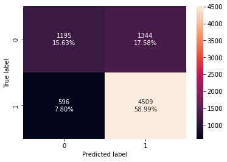

```python
xgb_tuned_model_train_perf=model_performance_classification_sklearn(xgb_tuned,X_train,y_train)
print("Training performance:\n",xgb_tuned_model_train_perf)
xgb_tuned_model_test_perf=model_performance_classification_sklearn(xgb_tuned,X_test,y_test)
print("Testing performance:\n",xgb_tuned_model_test_perf)

#Creating confusion matrix
confusion_matrix_sklearn(xgb_tuned,X_test,y_test)
```

Tuning the hyperparameter on the XGBoost has reduced the overfitting and improved the model

Stacking Classifier

```python
estimators = [('Random Forest',rf_tuned), ('Gradient Boosting',gbc_tuned), ('Decision Tree',dtree_estimator)]

final_estimator = xgb_tuned

stacking_classifier= StackingClassifier(estimators=estimators,final_estimator=final_estimator)

stacking_classifier.fit(X_train,y_train)
```

```
StackingClassifier(estimators=[('Random Forest',
                                RandomForestClassifier(class_weight={0: 0.18,
                                                                     1: 0.82},
                                                       max_features=None,
                                                       min_samples_leaf=6,
                                                       min_samples_split=17,
                                                       n_estimators=50,
                                                       oob_score=True,
                                                       random_state=1)),
                               ('Gradient Boosting',
                                GradientBoostingClassifier(init=AdaBoostClassifier(random_state=1),
                                                           max_features=0.9,
                                                           random_state=1,
                                                           subsample=0.8)),
                               ('Decision...
                                                 eval_metric='logloss', gamma=0,
                                                 gpu_id=-1,
                                                 grow_policy='depthwise',
                                                 importance_type=None,
                                                 interaction_constraints='',
                                                 learning_rate=0.05,
                                                 max_bin=256,
                                                 max_cat_to_onehot=4,
                                                 max_delta_step=0, max_depth=6,
                                                 max_leaves=0,
                                                 min_child_weight=1,
                                                 missing=nan,
                                                 monotone_constraints='()',
                                                 n_estimators=50, n_jobs=0,
                                                 num_parallel_tree=1,
                                                 predictor='auto',
                                                 random_state=1, reg_alpha=0,
                                                 reg_lambda=1, ...))
```

```
Training performance:
    Accuracy    Recall  Precision        F1
0  0.768894  0.894821   0.787937  0.837984
Testing performance:
    Accuracy    Recall  Precision        F1
0  0.744244  0.878159   0.770805  0.820987
```

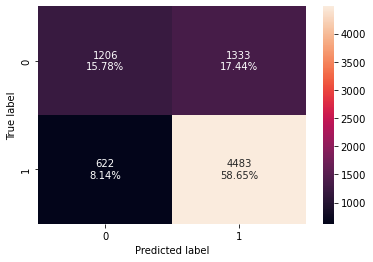

```python
stacking_classifier_model_train_perf=model_performance_classification_sklearn(stacking_classifier,X_train,y_train)
print("Training performance:\n",stacking_classifier_model_train_perf)
stacking_classifier_model_test_perf=model_performance_classification_sklearn(stacking_classifier,X_test,y_test)
print("Testing performance:\n",stacking_classifier_model_test_perf)

#Creating confusion matrix
confusion_matrix_sklearn(stacking_classifier,X_test,y_test)
```

## Will tuning the hyperparameters improve the model performance?

Overall, there has been slight improvements on the models with hyperparameter tuning

## Model Performance Comparison and Conclusions

```python
models_train_comp_df = pd.concat(
    [d_tree_model_train_perf.T,dtree_estimator_model_train_perf.T,rf_estimator_model_train_perf.T,rf_tuned_model_train_perf.T,
     bagging_classifier_model_train_perf.T,bagging_estimator_tuned_model_train_perf.T,ab_classifier_model_train_perf.T,
     abc_tuned_model_train_perf.T,gb_classifier_model_train_perf.T,gbc_tuned_model_train_perf.T,xgb_classifier_model_train_perf.T,
    xgb_tuned_model_train_perf.T,stacking_classifier_model_train_perf.T],
    axis=1,
)
models_train_comp_df.columns = [
    "Decision Tree",
    "Decision Tree Estimator",
    "Random Forest Estimator",
    "Random Forest Tuned",
    "Bagging Classifier",
    "Bagging Estimator Tuned",
    "Adaboost Classifier",
    "Adabosst Classifier Tuned",
    "Gradient Boost Classifier",
    "Gradient Boost Classifier Tuned",
    "XGBoost Classifier",
    "XGBoost Classifier Tuned",
    "Stacking Classifier"]
print("Training performance comparison:")
models_train_comp_df
```

```
Training performance comparison:
```

|  | Decision Tree | Decision Tree Estimator | Random Forest Estimator | Random Forest Tuned | Bagging Classifier | Bagging Estimator Tuned | Adaboost Classifier | Adabosst Classifier Tuned | Gradient Boost Classifier | Gradient Boost Classifier Tuned | XGBoost Classifier | XGBoost Classifier Tuned | Stacking Classifier |
| --- | --- | --- | --- | --- | --- | --- | --- | --- | --- | --- | --- | --- | --- |
| Accuracy | 1.0 | 1.0 | 1.0 | 0.776127 | 0.984357 | 0.993272 | 0.738058 | 0.755214 | 0.759587 | 0.758017 | 0.832922 | 0.762335 | 0.768894 |
| Recall | 1.0 | 1.0 | 1.0 | 0.998153 | 0.985646 | 0.997901 | 0.887266 | 0.884496 | 0.883237 | 0.882146 | 0.927642 | 0.893813 | 0.894821 |
| Precision | 1.0 | 1.0 | 1.0 | 0.749653 | 0.990886 | 0.992072 | 0.760486 | 0.778961 | 0.784112 | 0.783027 | 0.839168 | 0.781677 | 0.787937 |
| F1 | 1.0 | 1.0 | 1.0 | 0.856238 | 0.988259 | 0.994978 | 0.818999 | 0.828381 | 0.830728 | 0.829636 | 0.881190 | 0.833993 | 0.837984 |

```python
models_test_comp_df = pd.concat(
    [d_tree_model_test_perf.T,dtree_estimator_model_test_perf.T,rf_estimator_model_test_perf.T,rf_tuned_model_test_perf.T,
     bagging_classifier_model_test_perf.T,bagging_estimator_tuned_model_test_perf.T,ab_classifier_model_test_perf.T,
     abc_tuned_model_test_perf.T,gb_classifier_model_test_perf.T,gbc_tuned_model_test_perf.T,xgb_classifier_model_test_perf.T,
    xgb_tuned_model_test_perf.T,stacking_classifier_model_test_perf.T],
    axis=1,
)
models_test_comp_df.columns = [
    "Decision Tree",
    "Decision Tree Estimator",
    "Random Forest Estimator",
    "Random Forest Tuned",
    "Bagging Classifier",
    "Bagging Estimator Tuned",
    "Adaboost Classifier",
    "Adabosst Classifier Tuned",
    "Gradient Boost Classifier",
    "Gradient Boost Classifier Tuned",
    "XGBoost Classifier",
    "XGBoost Classifier Tuned",
    "Stacking Classifier"]
print("Testing performance comparison:")
models_test_comp_df
```

```
Testing performance comparison:
```

|  | Decision Tree | Decision Tree Estimator | Random Forest Estimator | Random Forest Tuned | Bagging Classifier | Bagging Estimator Tuned | Adaboost Classifier | Adabosst Classifier Tuned | Gradient Boost Classifier | Gradient Boost Classifier Tuned | XGBoost Classifier | XGBoost Classifier Tuned | Stacking Classifier |
| --- | --- | --- | --- | --- | --- | --- | --- | --- | --- | --- | --- | --- | --- |
| Accuracy | 0.658032 | 0.658032 | 0.724097 | 0.713370 | 0.693354 | 0.728545 | 0.734171 | 0.741235 | 0.745552 | 0.745160 | 0.729853 | 0.746206 | 0.744244 |
| Recall | 0.740059 | 0.740059 | 0.838198 | 0.955926 | 0.766699 | 0.860529 | 0.884231 | 0.878550 | 0.874045 | 0.876592 | 0.856807 | 0.883252 | 0.878159 |
| Precision | 0.745903 | 0.745903 | 0.769328 | 0.712825 | 0.772449 | 0.763204 | 0.758018 | 0.767585 | 0.774115 | 0.772484 | 0.766293 | 0.770374 | 0.770805 |
| F1 | 0.742970 | 0.742970 | 0.802287 | 0.816668 | 0.769564 | 0.808949 | 0.816275 | 0.819328 | 0.821051 | 0.821252 | 0.809026 | 0.822960 | 0.820987 |

Recall on random forest tuned on both the training and test parameters seems to give the best result, with only 2.9% error on the false negative of the confusion matrix

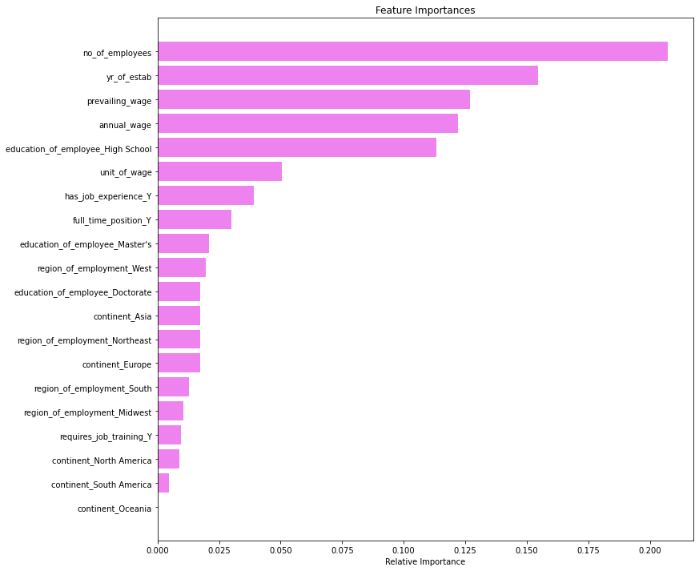

```python
feature_names = X_train.columns
importances = rf_tuned.feature_importances_
indices = np.argsort(importances)

plt.figure(figsize=(12,12))
plt.title('Feature Importances')
plt.barh(range(len(indices)), importances[indices], color='violet', align='center')
plt.yticks(range(len(indices)), [feature_names[i] for i in indices])
plt.xlabel('Relative Importance')
plt.show()
```

## Actionable Insights and Recommendations

Based on our analysis, we can say that the most significant factors that influence the certification or denial of visas are:

Companies with high number of employees which can be seen as size of the company

The year of establishment of the company which can also be regarded as the reputation of the company

The wages paid by companies is also a significant influence in visa certification or denial

Education of employees and job experience also have noticeable influence.

In certifying visas, applicants with combinations of the above criteria's should be prioritized to fasttrack the process.

Continents of applicant's origin and regions of employment should not be a material criteria for visa certification.

A good match of reputable employers and qualified employees should be encourages to reduce denial of applications.